# Thesis Analyses (IC)

2023-11-24

## Part 1

### Intro

Let’s start by loading in our packages:

```r
library(tidyverse)
library(readxl)
library(rstatix)
library(ggpubr)
library(ez)
library(emmeans)
library(car)
library(Hmisc)
library(corrplot)
library(multcomp)
library(lme4)
library(writexl)
```

Now let’s take a second to think about the data we have. Overall I have seven days on the full paradigm without injection, two full days with either saline or naltrexone injection, two days with either pure fat or pure sugar only, and a final two days with each animal’s favorite diet ( measured as mean average kcal eaten per day) following either saline or naltrexone injection.

My prospectus calls for 5 days of full paradigm training and 3 days of full paradigm testing, after which each animal’s favorite diet was to be calculated from the 3 test days. For some reason, what we did instead was use all 7 days to calculate favorite diet. I think that’s fine, but it leaves as an open question what we’re calling training and what we’re calling testing.

I think for now, the best thing to do is to stick as close to my prospectus as I can. I need at least 3 days of test data, so that leaves the four previous days as training data. Let’s start there.

### Data Prep

Let’s read in our data:

```r
#Vector for column names and diet names
column_names <- c("rat", "zero", "twenty", "forty", "sixty", "eighty", "hundred", "h2o", "day")
diet_names <- c("zero", "twenty", "forty", "sixty", "eighty", "hundred")
rat_names <- c("IC1", "IC2", "IC3", "IC4", "IC5", "IC6", "IC7", "IC8", "IC9", "IC10", "IC11", "IC12")

datap1_grams_wide <- read_excel("IC Test Data.xlsx", sheet = 14, range = "A3:I38", col_names = column_names)
datap1_kcal_wide <- read_excel("IC Test Data.xlsx", sheet = 14, range = "K3:S38", col_names = column_names)

#Convert negative values to zeroes
datap1_grams_filtered <- datap1_grams_wide
datap1_grams_filtered[datap1_grams_filtered < 0] <- 0

datap1_kcal_filtered <- datap1_kcal_wide
datap1_kcal_filtered[datap1_kcal_filtered < 0] <- 0

#Drop water for now
datap1_grams_filtered2 <- datap1_grams_filtered %>%
  subset(select = -c(h2o))

datap1_kcal_filtered2 <- datap1_kcal_filtered %>%
  subset(select = -c(h2o))

#Pivot to long format
datap1_grams <- datap1_grams_filtered2 %>%
  pivot_longer(cols = diet_names, names_to = "diet", values_to = "grams")
datap1_grams$day <- factor(datap1_grams$day,
                           levels = c("1", "2", "3"))
datap1_grams$diet <- factor(datap1_grams$diet,
                            levels = diet_names)
datap1_grams$rat <- factor(datap1_grams$rat,
                            levels = rat_names)

datap1_kcals <- datap1_kcal_filtered2 %>%
   pivot_longer(cols = diet_names, names_to = "diet", values_to = "kcals")
datap1_kcals$day <- factor(datap1_kcals$day,
                           levels = c("1", "2", "3"))
datap1_kcals$diet <- factor(datap1_kcals$diet,
                            levels = diet_names)
datap1_kcals$rat <- factor(datap1_kcals$rat,
                            levels = rat_names)
```

### Initial Vizualizations

Now just like normally, I think the best thing to do is to look at some visualizations before I do anything else

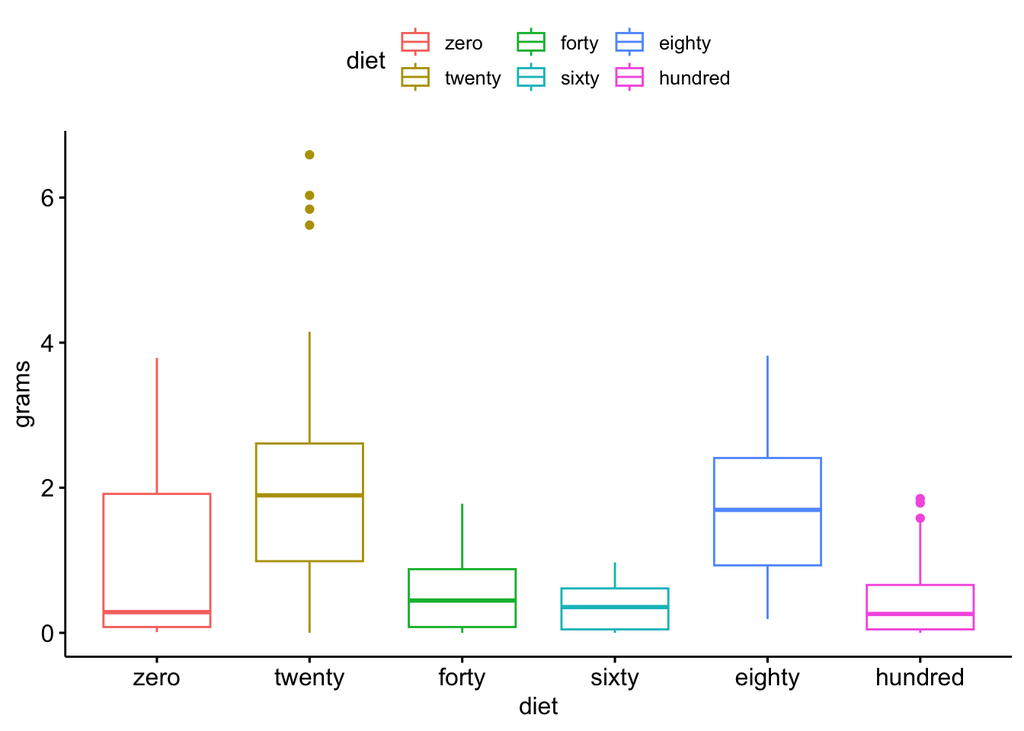

```r
ggboxplot(datap1_grams,
          x = "diet", y = "grams", color = "diet")
```

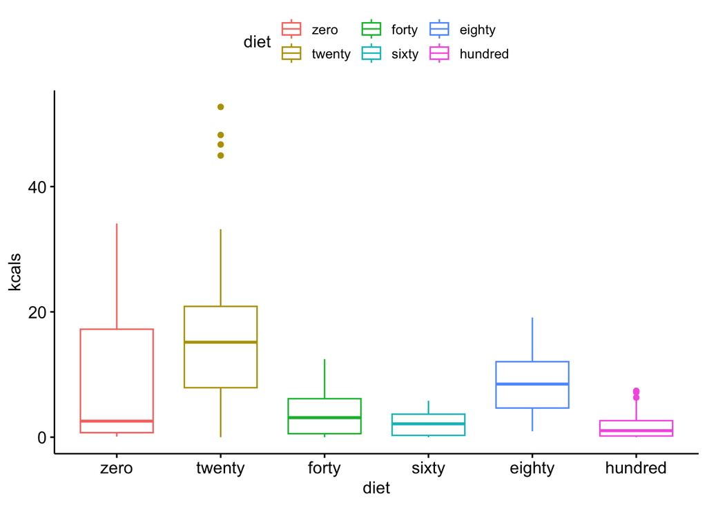

```r
ggboxplot(datap1_kcals,
          x = "diet", y = "kcals", color = "diet")
```

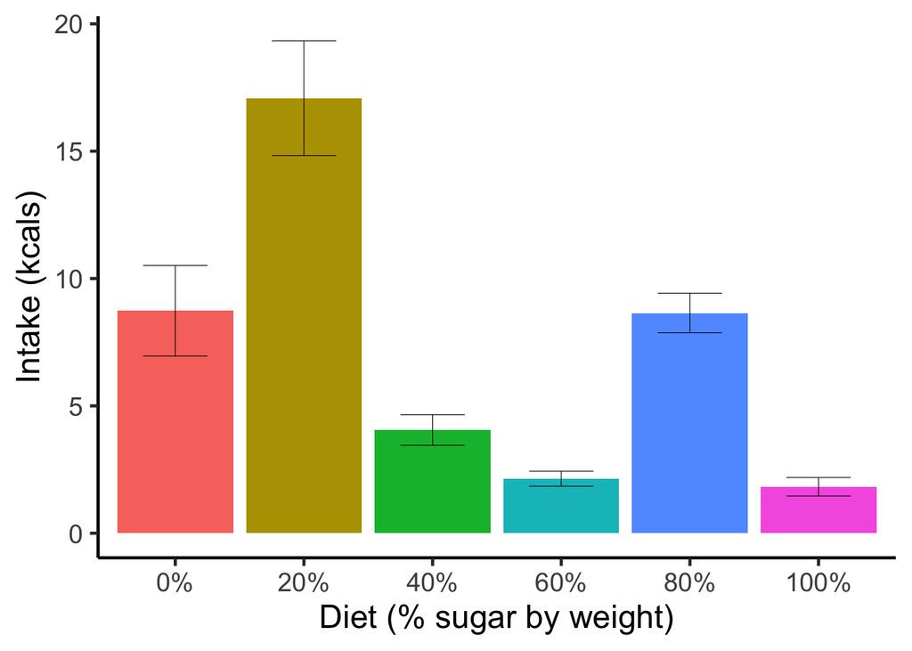

```r
## Kcal bar graph
#mean calories for each rat (collapsed across days, conditions, and drug condition)
meanKcals_groupedByDiet <- datap1_kcals %>%
  group_by(diet) %>%
  summarise(kcals = mean(kcals))

#SD's
SEKcals_groupedByDiet <- datap1_kcals %>%
  group_by(diet) %>%
  summarise(sd = sd(kcals),
            n = n(),
            se = sd/sqrt(n))

#Merge data frames
data_groupedByDiet <- inner_join(meanKcals_groupedByDiet,
                                 SEKcals_groupedByDiet,
                                by = "diet" )

data_groupedByDiet$diet <- factor(data_groupedByDiet$diet,
                                       levels = diet_names)

#Make plot
my_diet_labels <- setNames(c("0%", "20%", "40%", "60%", "80%", "100%"),
                           diet_names)


data_groupedByDiet %>%
  ggplot(mapping = aes(x = diet,
                       y = kcals,
                       fill = diet,
                       ymin = kcals - se,
                       ymax = kcals + se)) +
  geom_col(show.legend = FALSE) +
  geom_errorbar(position = position_dodge(0.9),
                width = 0.5,
                size = 0.2) +
  scale_x_discrete(labels = my_diet_labels) +
  labs(x = "Diet (% sugar by weight)",
       y = "Intake (kcals)") +
  theme_classic(base_size = 18)
```

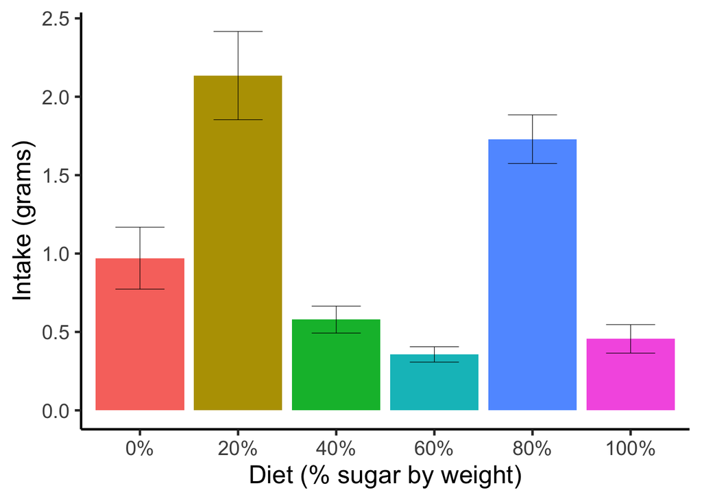

```r
## Gram bar graph
#mean calories for each rat (collapsed across days, conditions, and drug condition)
meanGrams_groupedByDiet <- datap1_grams %>%
  group_by(diet) %>%
  summarise(grams = mean(grams))

#SD's
SEGrams_groupedByDiet <- datap1_grams %>%
  group_by(diet) %>%
  summarise(sd = sd(grams),
            n = n(),
            se = sd/sqrt(n))

#Merge data frames
data_groupedByDiet <- inner_join(meanGrams_groupedByDiet,
                                 SEGrams_groupedByDiet,
                                by = "diet" )

data_groupedByDiet$diet <- factor(data_groupedByDiet$diet,
                                       levels = diet_names)

#Make plot
my_diet_labels <- setNames(c("0%", "20%", "40%", "60%", "80%", "100%"),
                           diet_names)


data_groupedByDiet %>%
  ggplot(mapping = aes(x = diet,
                       y = grams,
                       fill = diet,
                       ymin = grams - se,
                       ymax = grams + se)) +
  geom_col(show.legend = FALSE) +
  geom_errorbar(position = position_dodge(0.9),
                width = 0.5,
                size = 0.2) +
  scale_x_discrete(labels = my_diet_labels) +
  labs(x = "Diet (% sugar by weight)",
       y = "Intake (grams)") +
  theme_classic(base_size = 18)
```

This is interesting, and very different from the ID data. Here, it looks like there was a bifurcation between twenty and eighty percent as favorite diets. I already knew this since we had to give each rat it’s favorite diet later in the study, but it’s interesting to see it look so pronounced here.

Next let’s facet this by rat to see the breakdown for each individual:

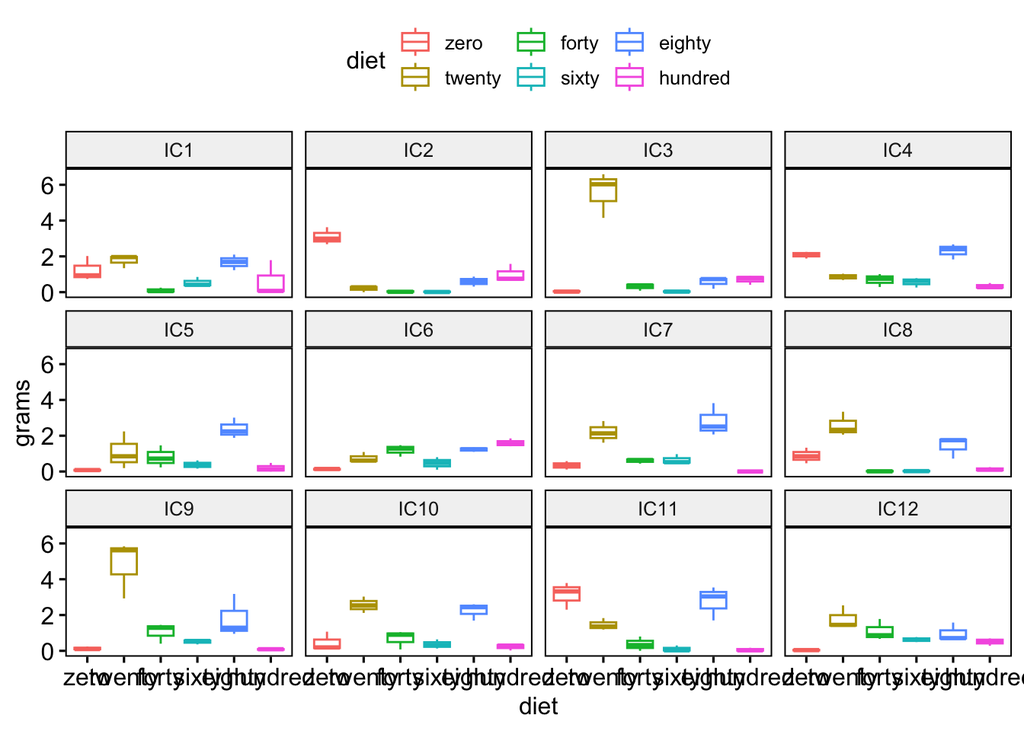

```r
ggboxplot(datap1_grams,
          x = "diet", y = "grams", color = "diet", facet.by = "rat")
```

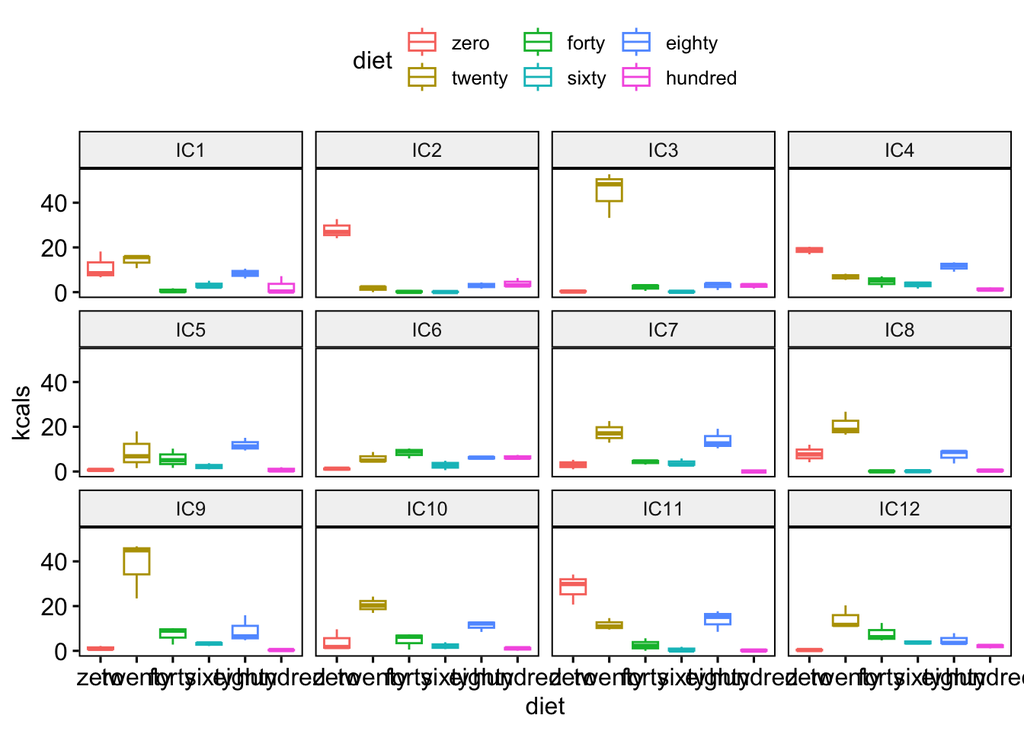

```r
ggboxplot(datap1_kcals,
          x = "diet", y = "kcals", color = "diet", facet.by = "rat")
```

Again, very much not the same as the ID data. It looks like rats run the gamut of favorite diets. These change some between datasets (which means I’ll have to justify using caloric intake to choose favorite diets; shit), but not overwhelmingly. I wish we’d given DAMGO to these animals–we may have seen something really cool.

In any case, because we’re including day as a dependent variable in the final analysis, I want to get a sense of how much this picture changes by day:

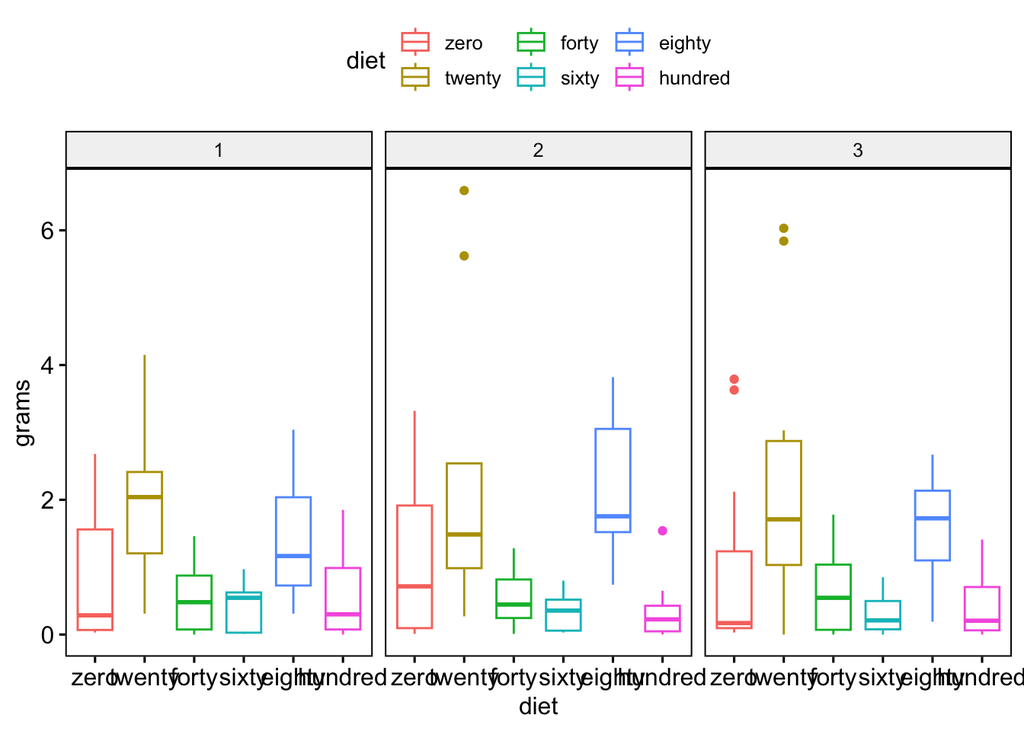

```r
ggboxplot(datap1_grams,
          x = "diet", y = "grams", color = "diet", facet.by = "day")
```

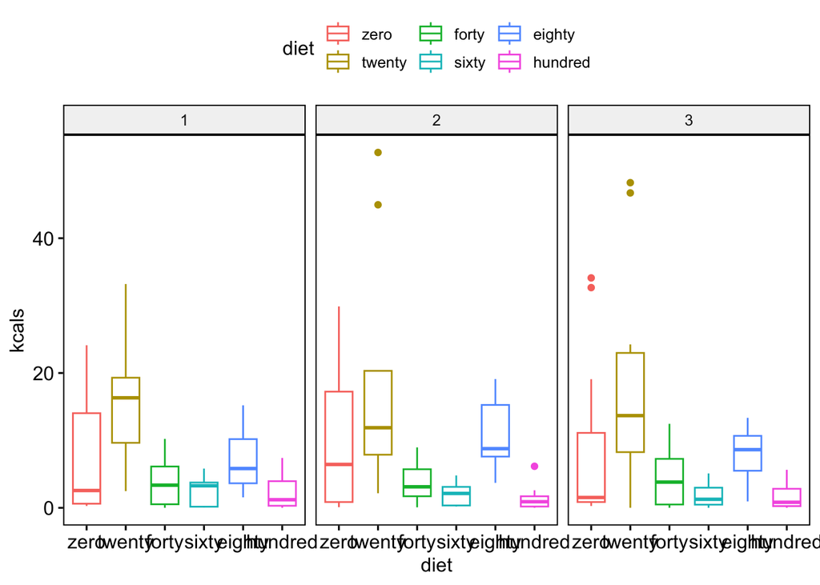

```r
ggboxplot(datap1_kcals,
          x = "diet", y = "kcals", color = "diet", facet.by = "day")
```

### Inferential Analysis

Now for the part we’ve all been waiting for, the inferential analysis:

```r
res.aovGrams = anova_test(
  data = datap1_grams,
  dv = grams,
  wid = rat,
  within = c(diet, day),
  type = 2
)
get_anova_table(res.aovGrams)
```

```
## ANOVA Table (type II tests)
##
##     Effect  DFn    DFd     F     p p<.05   ges
## 1     diet  2.1  23.06 6.753 0.004     * 0.330
## 2      day  2.0  22.00 2.441 0.110       0.003
## 3 diet:day 10.0 110.00 1.597 0.117       0.020
```

```r
#trying it a different way
exp2Grams <- aov(grams ~ diet*day + Error(rat/(diet*day)), data = datap1_grams)
summary(exp2Grams)
```

```
##
## Error: rat
##           Df Sum Sq Mean Sq F value Pr(>F)
## Residuals 11  7.975   0.725
##
## Error: rat:diet
##           Df Sum Sq Mean Sq F value   Pr(>F)
## diet       5  97.21  19.442   6.753 5.68e-05 ***
## Residuals 55 158.34   2.879
## ---
## Signif. codes:  0 '***' 0.001 '**' 0.01 '*' 0.05 '.' 0.1 ' ' 1
##
## Error: rat:day
##           Df Sum Sq Mean Sq F value Pr(>F)
## day        2 0.6495  0.3248   2.441   0.11
## Residuals 22 2.9270  0.1330
##
## Error: rat:diet:day
##            Df Sum Sq Mean Sq F value Pr(>F)
## diet:day   10  4.081  0.4081   1.597  0.117
## Residuals 110 28.116  0.2556
```

```r
#And a third way because the first two don't match
grams.aov <- ezANOVA(data = datap1_grams,
                    dv = .(grams),
                    wid = .(rat),
                    within = .(diet, day),
                    return_aov = TRUE,
                    type = 2)
grams.aov$ANOVA
```

```
##     Effect DFn DFd        F            p p<.05         ges
## 2     diet   5  55 6.753059 5.682651e-05     * 0.330003007
## 3      day   2  22 2.440963 1.103025e-01       0.003280235
## 4 diet:day  10 110 1.596698 1.168044e-01       0.020259778
```

The specific numbers between the alternate methods I’m using vary, but they all tell the same basic story. We have a main effect of diet, no effect of day, and no interaction. That’s good, because a main effect of diet is all we were looking for.

Let’s look further into this by using pairwise within subjects t-tests to see how diet groups differed from each other:

```r
pairwiseGrams <- datap1_grams %>%
  pairwise_t_test(grams~diet, paired = TRUE,
                  p.adjust.method = "bonferroni")
pairwiseGrams
```

```
## # A tibble: 15 × 10
##    .y.   group1 group2    n1    n2 statistic    df        p   p.adj p.adj.signif
##  * <chr> <chr>  <chr>  <int> <int>     <dbl> <dbl>    <dbl>   <dbl> <chr>
##  1 grams zero   twenty    36    36    -2.83     35 8   e- 3 1.16e-1 ns
##  2 grams zero   forty     36    36     1.60     35 1.18e- 1 1   e+0 ns
##  3 grams zero   sixty     36    36     2.81     35 8   e- 3 1.2 e-1 ns
##  4 grams zero   eighty    36    36    -3.10     35 4   e- 3 5.7 e-2 ns
##  5 grams zero   hundr…    36    36     2.31     35 2.7 e- 2 4.04e-1 ns
##  6 grams twenty forty     36    36     5.35     35 5.49e- 6 8.24e-5 ****
##  7 grams twenty sixty     36    36     6.11     35 5.54e- 7 8.31e-6 ****
##  8 grams twenty eighty    36    36     1.20     35 2.4 e- 1 1   e+0 ns
##  9 grams twenty hundr…    36    36     5.31     35 6.22e- 6 9.33e-5 ****
## 10 grams forty  sixty     36    36     2.79     35 9   e- 3 1.28e-1 ns
## 11 grams forty  eighty    36    36    -6.37     35 2.55e- 7 3.82e-6 ****
## 12 grams forty  hundr…    36    36     0.992    35 3.28e- 1 1   e+0 ns
## 13 grams sixty  eighty    36    36    -8.94     35 1.45e-10 2.18e-9 ****
## 14 grams sixty  hundr…    36    36    -0.909    35 3.69e- 1 1   e+0 ns
## 15 grams eighty hundr…    36    36     5.92     35 9.89e- 7 1.48e-5 ****
```

So from this it looks like even with Bonferroni corrections we have a decent number of significant comparisons. 80% and 20% don’t actually significantly differ from each other (which is fascinating) but they’re more consumed than pretty much everything else.

And finally, let’s do an explicit contrast comparing the individual diets with the blends:

```r
#grams.em1 <- emmeans(grams.aov$aov, ~diet * day)

#contrast_names <- list(c(2, -1, -1, -1, -1, 2,
 #                        2, -1, -1, -1, -1, 2,
  #                       2, -1, -1, -1, -1, 2))
#contrast(grams.em1,
 #        method = contrast_names)
```

For completeness sake, I want to do this all over again with the calorie data

```r
#trying it a different way
exp2Kcals <- aov(kcals ~ diet*day + Error(rat/(diet*day)), data = datap1_kcals)
summary(exp2Kcals)
```

```
##
## Error: rat
##           Df Sum Sq Mean Sq F value Pr(>F)
## Residuals 11  544.3   49.48
##
## Error: rat:diet
##           Df Sum Sq Mean Sq F value   Pr(>F)
## diet       5   5991  1198.2   6.874 4.79e-05 ***
## Residuals 55   9587   174.3
## ---
## Signif. codes:  0 '***' 0.001 '**' 0.01 '*' 0.05 '.' 0.1 ' ' 1
##
## Error: rat:day
##           Df Sum Sq Mean Sq F value Pr(>F)
## day        2  33.91  16.953    2.18  0.137
## Residuals 22 171.12   7.778
##
## Error: rat:diet:day
##            Df Sum Sq Mean Sq F value Pr(>F)
## diet:day   10    122   12.20   0.954  0.487
## Residuals 110   1407   12.79
```

```r
#And a third way because the first two don't match
kcals.aov <- ezANOVA(data = datap1_kcals,
                    dv = .(kcals),
                    wid = .(rat),
                    within = .(diet, day),
                    return_aov = TRUE,
                    type = 2)
kcals.aov$ANOVA
```

```
##     Effect DFn DFd         F            p p<.05         ges
## 2     diet   5  55 6.8739282 0.0000478648     * 0.338468008
## 3      day   2  22 2.1795623 0.1369016453       0.002887454
## 4 diet:day  10 110 0.9541419 0.4874560898       0.010313709
```

```r
pairwiseKcals <- datap1_kcals %>%
  pairwise_t_test(kcals~diet, paired = TRUE,
                  p.adjust.method = "bonferroni")
pairwiseKcals
```

```
## # A tibble: 15 × 10
##    .y.   group1 group2    n1    n2 statistic    df        p   p.adj p.adj.signif
##  * <chr> <chr>  <chr>  <int> <int>     <dbl> <dbl>    <dbl>   <dbl> <chr>
##  1 kcals zero   twenty    36    36   -2.41      35 2.1 e- 2 3.16e-1 ns
##  2 kcals zero   forty     36    36    2.24      35 3.2 e- 2 4.73e-1 ns
##  3 kcals zero   sixty     36    36    3.48      35 1   e- 3 2   e-2 *
##  4 kcals zero   eighty    36    36    0.0461    35 9.63e- 1 1   e+0 ns
##  5 kcals zero   hundr…    36    36    3.76      35 6.2 e- 4 9   e-3 **
##  6 kcals twenty forty     36    36    5.65      35 2.22e- 6 3.33e-5 ****
##  7 kcals twenty sixty     36    36    6.49      35 1.78e- 7 2.67e-6 ****
##  8 kcals twenty eighty    36    36    3.40      35 2   e- 3 2.5 e-2 *
##  9 kcals twenty hundr…    36    36    6.45      35 2   e- 7 3   e-6 ****
## 10 kcals forty  sixty     36    36    3.47      35 1   e- 3 2.1 e-2 *
## 11 kcals forty  eighty    36    36   -4.58      35 5.63e- 5 8.44e-4 ***
## 12 kcals forty  hundr…    36    36    3.20      35 3   e- 3 4.4 e-2 *
## 13 kcals sixty  eighty    36    36   -8.39      35 6.71e-10 1.01e-8 ****
## 14 kcals sixty  hundr…    36    36    0.636     35 5.29e- 1 1   e+0 ns
## 15 kcals eighty hundr…    36    36    6.78      35 7.38e- 8 1.11e-6 ****
```

```r
#kcals.em1 <- emmeans(kcals.aov$aov, ~diet * day)

#contrast_names <- list(c(2, -1, -1, -1, -1, 2,
 #                        2, -1, -1, -1, -1, 2,
  #                       2, -1, -1, -1, -1, 2))
#contrast(kcals.em1,
 #        method = contrast_names)
```

So again, a similar story. So far, things are looking how we expected!

## Part 2

### Data Prep

Now to analyze the data from part 2! Let’s read it in the same way as for the last experiment

```r
column_names_p2 <- c("rat", "zero", "twenty", "forty", "sixty", "eighty", "hundred", "h2o", "condition")

datap2_grams_wide <- read_excel("IC Test Data.xlsx", sheet = 15, range = "A3:I26", col_names = column_names_p2)
datap2_kcal_wide <- read_excel("IC Test Data.xlsx", sheet = 15, range = "K3:S26", col_names = column_names_p2)

#Convert negative values to zeroes
datap2_grams_filtered <- datap2_grams_wide
datap2_grams_filtered[datap2_grams_filtered < 0] <- 0

datap2_kcal_filtered <- datap2_kcal_wide
datap2_kcal_filtered[datap2_kcal_filtered < 0] <- 0

#Drop water for now
datap2_grams_filtered2 <- datap2_grams_filtered %>%
  subset(select = -c(h2o))

datap2_kcal_filtered2 <- datap2_kcal_filtered %>%
  subset(select = -c(h2o))

#Pivot to long format
datap2_grams <- datap2_grams_filtered2 %>%
  pivot_longer(cols = diet_names, names_to = "diet", values_to = "grams")
datap2_grams$condition <- factor(datap2_grams$condition,
                           levels = c("NAL", "VEH"))
datap2_grams$diet <- factor(datap2_grams$diet,
                            levels = diet_names)
datap2_grams$rat <- factor(datap2_grams$rat,
                            levels = rat_names)

datap2_kcals <- datap2_kcal_filtered2 %>%
   pivot_longer(cols = diet_names, names_to = "diet", values_to = "kcals")
datap2_kcals$condition <- factor(datap2_kcals$condition,
                           levels = c("NAL", "VEH"))
datap2_kcals$diet <- factor(datap2_kcals$diet,
                            levels = diet_names)
datap2_kcals$rat <- factor(datap2_kcals$rat,
                            levels = rat_names)
```

### Initial Vizualizations

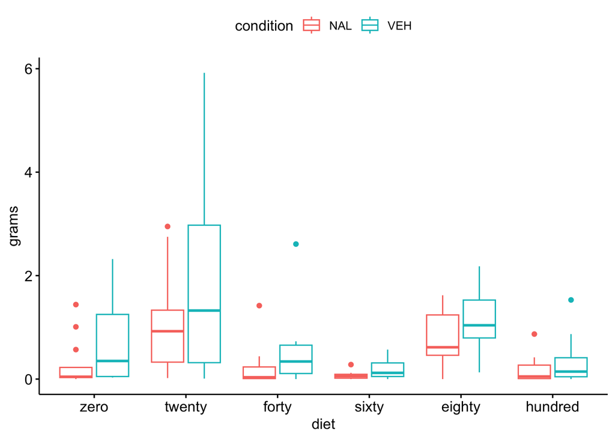

```r
ggboxplot(datap2_grams,
          x = "diet", y = "grams", color = "condition")
```

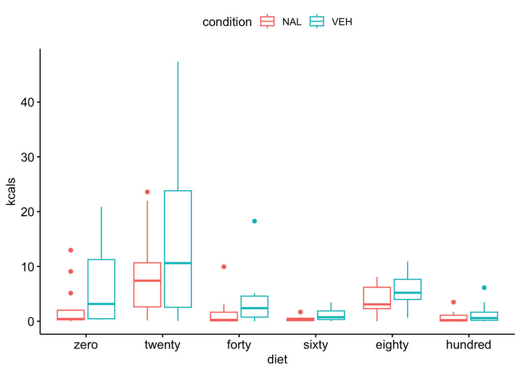

```r
ggboxplot(datap2_kcals,
          x = "diet", y = "kcals", color = "condition")
```

```r
##Kcals
#mean calories for each rat (collapsed across days, conditions, and drug condition)
meanKcals_groupedByDiet <- datap2_kcals %>%
  group_by(diet, condition) %>%
  summarise(kcal = mean(kcals))
#SD's
SEKcals_groupedByDiet <- datap2_kcals %>%
  group_by(diet, condition) %>%
  summarise(n = n(),
            sd = sd(kcals),
            se = sd/sqrt(n))
```

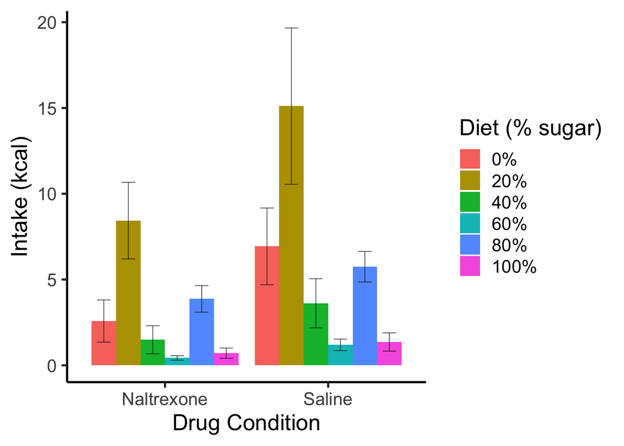

```r
#Merge data frames
data_groupedByDiet <- inner_join(meanKcals_groupedByDiet,
                                 SEKcals_groupedByDiet,
                                 by = c("diet", "condition"))


data_groupedByDiet$diet <- factor(data_groupedByDiet$diet,
                                       levels = diet_names)

#Make plot
my_x_labels <- setNames(c("Naltrexone", "Saline"),
                        c("NAL", "VEH"))
my_fill_labels <- setNames(c("0%", "20%", "40%", "60%", "80%", "100%"),
                           diet_names)



data_groupedByDiet %>%
  ggplot(mapping = aes(x = condition,
                       y = kcal,
                       fill = diet,
                       ymin = kcal - se,
                       ymax = kcal + se)) +
  geom_col(position = "dodge") +
  geom_errorbar(position = position_dodge(0.9),
                width = 0.5,
                size = 0.2) +
  scale_x_discrete(labels = my_x_labels) +
  scale_fill_discrete(labels = my_fill_labels) +
  labs(x = "Drug Condition",
       y = "Intake (kcal)",
       fill = "Diet (% sugar)") +
  theme_classic(base_size = 18)
```

```r
##Grams
#mean calories for each rat (collapsed across days, conditions, and drug condition)
meanGrams_groupedByDiet <- datap2_grams %>%
  group_by(diet, condition) %>%
  summarise(grams = mean(grams))
#SD's
SEGrams_groupedByDiet <- datap2_grams %>%
  group_by(diet, condition) %>%
  summarise(n = n(),
            sd = sd(grams),
            se = sd/sqrt(n))
```

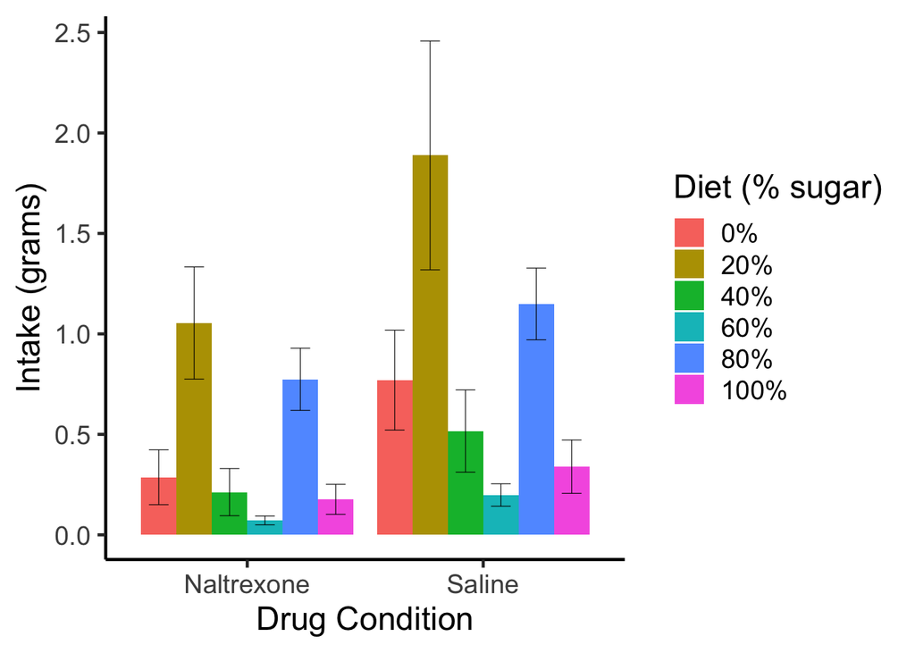

```r
#Merge data frames
data_groupedByDiet <- inner_join(meanGrams_groupedByDiet,
                                 SEGrams_groupedByDiet,
                                 by = c("diet", "condition"))


data_groupedByDiet$diet <- factor(data_groupedByDiet$diet,
                                       levels = diet_names)

#Make plot
my_x_labels <- setNames(c("Naltrexone", "Saline"),
                        c("NAL", "VEH"))
my_fill_labels <- setNames(c("0%", "20%", "40%", "60%", "80%", "100%"),
                           diet_names)



data_groupedByDiet %>%
  ggplot(mapping = aes(x = condition,
                       y = grams,
                       fill = diet,
                       ymin = grams - se,
                       ymax = grams + se)) +
  geom_col(position = "dodge") +
  geom_errorbar(position = position_dodge(0.9),
                width = 0.5,
                size = 0.2) +
  scale_x_discrete(labels = my_x_labels) +
  scale_fill_discrete(labels = my_fill_labels) +
  labs(x = "Drug Condition",
       y = "Intake (grams)",
       fill = "Diet (% sugar)") +
  theme_classic(base_size = 18)
```

Once again, the difference here is pretty stark. At least descriptively, naltrexone definitely decreased consumption, and it also functioned to sharply decrease the variability in the amount of each diet rats consumed.

### Inferential Analysis

Now for the part we’ve all been waiting for, the inferential analysis:

```r
# Method 1
exp2Grams2 <- aov(grams ~ diet*condition + Error(rat/(diet*condition)), data = datap2_grams)
summary(exp2Grams2)
```

```
##
## Error: rat
##           Df Sum Sq Mean Sq F value Pr(>F)
## Residuals 11  3.798  0.3453
##
## Error: rat:diet
##           Df Sum Sq Mean Sq F value   Pr(>F)
## diet       5  30.75   6.150   5.377 0.000428 ***
## Residuals 55  62.91   1.144
## ---
## Signif. codes:  0 '***' 0.001 '**' 0.01 '*' 0.05 '.' 0.1 ' ' 1
##
## Error: rat:condition
##           Df Sum Sq Mean Sq F value   Pr(>F)
## condition  1  5.225   5.225   29.77 0.000199 ***
## Residuals 11  1.931   0.176
## ---
## Signif. codes:  0 '***' 0.001 '**' 0.01 '*' 0.05 '.' 0.1 ' ' 1
##
## Error: rat:diet:condition
##                Df Sum Sq Mean Sq F value Pr(>F)
## diet:condition  5  2.005  0.4010   1.655  0.161
## Residuals      55 13.328  0.2423
```

```r
# Method 2
grams.aov2 <- ezANOVA(data = datap2_grams,
                    dv = .(grams),
                    wid = .(rat),
                    within = .(diet, condition),
                    return_aov = TRUE,
                    type = 2)
grams.aov2$ANOVA
```

```
##           Effect DFn DFd         F            p p<.05        ges
## 2           diet   5  55  5.376720 0.0004281572     * 0.27281043
## 3      condition   1  11 29.770614 0.0001989491     * 0.05992291
## 4 diet:condition   5  55  1.654921 0.1610449460       0.02387817
```

So we have main effects of diet and condition, but no interaction. So they consumed different amounts of the diets, and they consumed generally more on the saline day than the naltrexone day, but there wasn’t a difference in the effect of naltrexone between diets. A bit of a bummer because I was hoping to dig into that interaction further, but that’s real data for you.

In any case, let’s do our pairwise analyses

```r
pairwiseGrams2 <- datap2_grams %>%
  pairwise_t_test(grams~diet, paired = TRUE,
                  p.adjust.method = "bonferroni")
pairwiseGrams2
```

```
## # A tibble: 15 × 10
##    .y.   group1 group2     n1    n2 statistic    df       p   p.adj p.adj.signif
##  * <chr> <chr>  <chr>   <int> <int>     <dbl> <dbl>   <dbl>   <dbl> <chr>
##  1 grams zero   twenty     24    24    -2.53     23 1.9 e-2 2.79e-1 ns
##  2 grams zero   forty      24    24     0.806    23 4.28e-1 1   e+0 ns
##  3 grams zero   sixty      24    24     2.77     23 1.1 e-2 1.65e-1 ns
##  4 grams zero   eighty     24    24    -2.61     23 1.6 e-2 2.34e-1 ns
##  5 grams zero   hundred    24    24     1.49     23 1.51e-1 1   e+0 ns
##  6 grams twenty forty      24    24     3.18     23 4   e-3 6.3 e-2 ns
##  7 grams twenty sixty      24    24     4.11     23 4.31e-4 6   e-3 **
##  8 grams twenty eighty     24    24     1.37     23 1.85e-1 1   e+0 ns
##  9 grams twenty hundred    24    24     3.62     23 1   e-3 2.2 e-2 *
## 10 grams forty  sixty      24    24     2.04     23 5.3 e-2 7.95e-1 ns
## 11 grams forty  eighty     24    24    -3.05     23 6   e-3 8.4 e-2 ns
## 12 grams forty  hundred    24    24     0.906    23 3.75e-1 1   e+0 ns
## 13 grams sixty  eighty     24    24    -6.70     23 7.87e-7 1.18e-5 ****
## 14 grams sixty  hundred    24    24    -1.46     23 1.58e-1 1   e+0 ns
## 15 grams eighty hundred    24    24     4.52     23 1.54e-4 2   e-3 **
```

```r
#grams.em2 <- emmeans(grams.aov2$aov, ~diet * condition)

#contrast_names <- list(c(2, -1, -1, -1, -1, 2,
 #                        2, -1, -1, -1, -1, 2))
#contrast(grams.em2,
 #        method = contrast_names)
```

So a similar story as from part 1. I would argue in this part of the experiment the rats showed a slightly more pronounced preference for the 20% diet over the 80%, but inferentially the picture is pretty similar.

Again for completeness, let’s repeat things with the calorie data:

```r
#trying it a different way
exp2Kcals2 <- aov(kcals ~ diet*condition + Error(rat/(diet*condition)), data = datap2_kcals)
summary(exp2Kcals2)
```

```
##
## Error: rat
##           Df Sum Sq Mean Sq F value Pr(>F)
## Residuals 11  284.6   25.87
##
## Error: rat:diet
##           Df Sum Sq Mean Sq F value   Pr(>F)
## diet       5   1972   394.5   5.975 0.000175 ***
## Residuals 55   3631    66.0
## ---
## Signif. codes:  0 '***' 0.001 '**' 0.01 '*' 0.05 '.' 0.1 ' ' 1
##
## Error: rat:condition
##           Df Sum Sq Mean Sq F value   Pr(>F)
## condition  1  270.2  270.19   22.23 0.000635 ***
## Residuals 11  133.7   12.16
## ---
## Signif. codes:  0 '***' 0.001 '**' 0.01 '*' 0.05 '.' 0.1 ' ' 1
##
## Error: rat:diet:condition
##                Df Sum Sq Mean Sq F value Pr(>F)
## diet:condition  5  164.8   32.97   2.212  0.066 .
## Residuals      55  819.8   14.91
## ---
## Signif. codes:  0 '***' 0.001 '**' 0.01 '*' 0.05 '.' 0.1 ' ' 1
```

```r
#And a third way because the first two don't match
kcals.aov2 <- ezANOVA(data = datap2_kcals,
                    dv = .(kcals),
                    wid = .(rat),
                    within = .(diet, condition),
                    return_aov = TRUE,
                    type = 2)
kcals.aov2$ANOVA
```

```
##           Effect DFn DFd         F            p p<.05        ges
## 2           diet   5  55  5.975338 0.0001752719     * 0.28830112
## 3      condition   1  11 22.226484 0.0006350697     * 0.05257445
## 4 diet:condition   5  55  2.211806 0.0660384713       0.03274589
```

```r
pairwiseKcals2 <- datap2_kcals %>%
  pairwise_t_test(kcals~diet, paired = TRUE,
                  p.adjust.method = "bonferroni")
pairwiseKcals2
```

```
## # A tibble: 15 × 10
##    .y.   group1 group2     n1    n2 statistic    df       p   p.adj p.adj.signif
##  * <chr> <chr>  <chr>   <int> <int>     <dbl> <dbl>   <dbl>   <dbl> <chr>
##  1 kcals zero   twenty     24    24   -2.30      23 3.1 e-2 4.68e-1 ns
##  2 kcals zero   forty      24    24    1.32      23 2   e-1 1   e+0 ns
##  3 kcals zero   sixty      24    24    3.06      23 6   e-3 8.3 e-2 ns
##  4 kcals zero   eighty     24    24   -0.0406    23 9.68e-1 1   e+0 ns
##  5 kcals zero   hundred    24    24    2.60      23 1.6 e-2 2.42e-1 ns
##  6 kcals twenty forty      24    24    3.36      23 3   e-3 4   e-2 *
##  7 kcals twenty sixty      24    24    4.23      23 3.21e-4 5   e-3 **
##  8 kcals twenty eighty     24    24    2.49      23 2   e-2 3.08e-1 ns
##  9 kcals twenty hundred    24    24    4.11      23 4.28e-4 6   e-3 **
## 10 kcals forty  sixty      24    24    2.20      23 3.8 e-2 5.69e-1 ns
## 11 kcals forty  eighty     24    24   -1.91      23 6.8 e-2 1   e+0 ns
## 12 kcals forty  hundred    24    24    1.93      23 6.6 e-2 9.85e-1 ns
## 13 kcals sixty  eighty     24    24   -6.41      23 1.54e-6 2.31e-5 ****
## 14 kcals sixty  hundred    24    24   -0.602     23 5.53e-1 1   e+0 ns
## 15 kcals eighty hundred    24    24    5.16      23 3.15e-5 4.72e-4 ***
```

```r
#kcals.em2 <- emmeans(kcals.aov2$aov, ~diet * condition)

#contrast_names <- list(c(2, -1, -1, -1, -1, 2,
 #                        2, -1, -1, -1, -1, 2))
#contrast(kcals.em2,
 #        method = contrast_names)
```

A similar picture as with the weight data, but here the diet x condition interaction is very much approaching significance (p = .066). Maybe something to circle back to; perhaps baseline preferences did have a small impact on the effect of naltrexone.

## Part 3

### Data Prep

```r
column_names_p3 <- c("rat", "fav_blend", "fat", "sugar", "fav_blend_veh", "fav_blend_nal")
diet_names_3 <- c("fat", "sugar", "fav_blend_veh", "fav_blend_nal")

datap3_grams_wide <- read_excel("IC Test Data.xlsx", sheet = 16, range = "A3:F14", col_names = column_names_p3)
datap3_kcal_wide <- read_excel("IC Test Data.xlsx", sheet = 16, range = "I3:N14", col_names = column_names_p3)

#Convert negative values to zeroes
datap3_grams_filtered <- datap3_grams_wide
datap3_grams_filtered[datap3_grams_filtered < 0] <- 0

datap3_kcal_filtered <- datap3_kcal_wide
datap3_kcal_filtered[datap3_kcal_filtered < 0] <- 0


#Pivot to long format
datap3_grams <- datap3_grams_filtered %>%
  pivot_longer(cols = diet_names_3, names_to = "condition", values_to = "grams")
datap3_grams$condition <- factor(datap3_grams$condition,
                           levels = diet_names_3)
datap3_grams$rat <- factor(datap3_grams$rat,
                            levels = rat_names)
datap3_grams$fav_blend <- factor(datap3_grams$fav_blend,
                            levels = c("Twenty", "Eighty"))

datap3_kcals <- datap3_kcal_filtered %>%
  pivot_longer(cols = diet_names_3, names_to = "condition", values_to = "kcals")
datap3_grams$condition <- factor(datap3_grams$condition,
                           levels = diet_names_3)
datap3_grams$rat <- factor(datap3_grams$rat,
                            levels = rat_names)
datap3_grams$fav_blend <- factor(datap3_grams$fav_blend,
                            levels = c("Twenty", "Eighty"))
```

### Initial visualizations

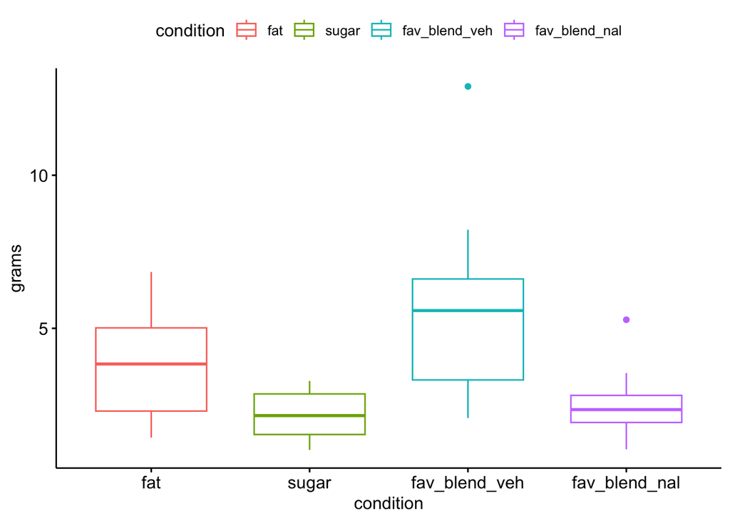

```r
ggboxplot(datap3_grams,
          x = "condition", y = "grams", color = "condition")
```

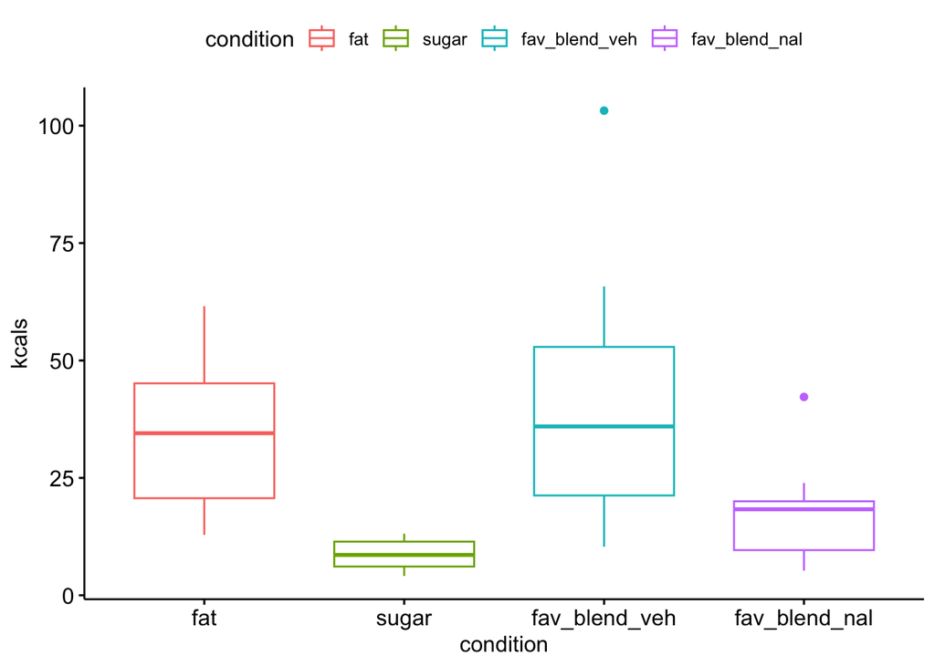

```r
ggboxplot(datap3_kcals,
          x = "condition", y = "kcals", color = "condition")
```

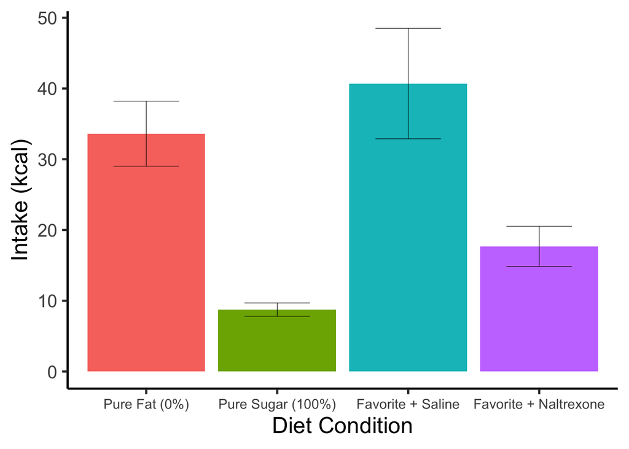

```r
## Kcal bar graph
#mean calories for each rat (collapsed across days, conditions, and drug condition)
meanKcals_groupedByDiet <- datap3_kcals %>%
  group_by(condition) %>%
  summarise(kcals = mean(kcals))

#SD's
SEKcals_groupedByDiet <- datap3_kcals %>%
  group_by(condition) %>%
  summarise(sd = sd(kcals),
            n = n(),
            se = sd/sqrt(n))

#Merge data frames
data_groupedByDiet <- inner_join(meanKcals_groupedByDiet,
                                 SEKcals_groupedByDiet,
                                by = "condition" )
data_groupedByDiet$condition <- factor(data_groupedByDiet$condition,
                                       levels = diet_names_3)

#Make plot
my_diet_labels <- setNames(c("Pure Fat (0%)", "Pure Sugar (100%)", "Favorite + Saline", "Favorite + Naltrexone"),
                           diet_names_3)


data_groupedByDiet %>%
  ggplot(mapping = aes(x = condition,
                       y = kcals,
                       fill = condition,
                       ymin = kcals - se,
                       ymax = kcals + se)) +
  geom_col(show.legend = FALSE) +
  geom_errorbar(position = position_dodge(0.9),
                width = 0.5,
                size = 0.2) +
  scale_x_discrete(labels = my_diet_labels) +
  labs(x = "Diet Condition",
       y = "Intake (kcal)") +
  theme_classic(base_size = 18) +
  theme(axis.text.x = element_text(size = 11))
```

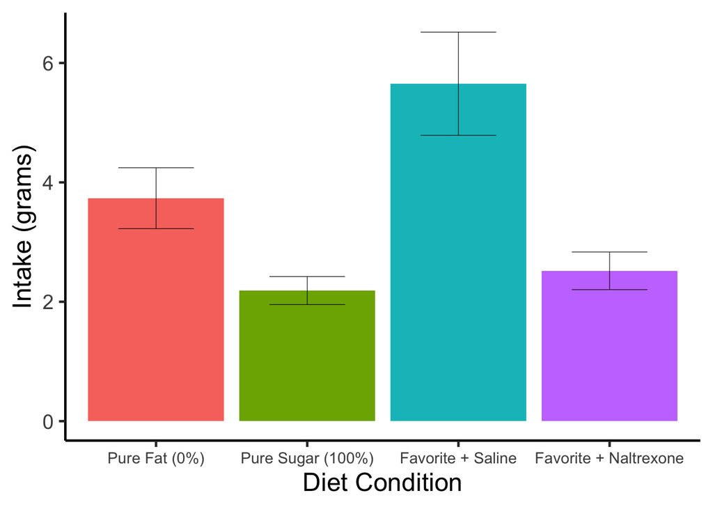

```r
## Gram bar graph
#mean calories for each rat (collapsed across days, conditions, and drug condition)
meanGrams_groupedByDiet <- datap3_grams %>%
  group_by(condition) %>%
  summarise(grams = mean(grams))

#SD's
SEGrams_groupedByDiet <- datap3_grams %>%
  group_by(condition) %>%
  summarise(sd = sd(grams),
            n = n(),
            se = sd/sqrt(n))

#Merge data frames
data_groupedByDiet <- inner_join(meanGrams_groupedByDiet,
                                 SEGrams_groupedByDiet,
                                by = "condition" )

#Make plot


data_groupedByDiet %>%
  ggplot(mapping = aes(x = condition,
                       y = grams,
                       fill = condition,
                       ymin = grams - se,
                       ymax = grams + se)) +
  geom_col(show.legend = FALSE) +
  geom_errorbar(position = position_dodge(0.9),
                width = 0.5,
                size = 0.2) +
  scale_x_discrete(labels = my_diet_labels) +
  labs(x = "Diet Condition",
       y = "Intake (grams)") +
  theme_classic(base_size = 18) +
  theme(axis.text.x = element_text(size = 11))
```

Things actually don’t look as different between the kcal and weight data as I expected. However, I think it’s going to be particularly important to present both pictures here so that the reader can draw their own conclusions.

### Inferential analyses

#### Grams

```r
# Method 1
exp2Grams3 <- aov(grams ~ condition + Error(rat/condition), data = datap3_grams)
summary(exp2Grams3)
```

```
##
## Error: rat
##           Df Sum Sq Mean Sq F value Pr(>F)
## Residuals 11   84.2   7.655
##
## Error: rat:condition
##           Df Sum Sq Mean Sq F value   Pr(>F)
## condition  3  88.47  29.491   14.06 4.52e-06 ***
## Residuals 33  69.23   2.098
## ---
## Signif. codes:  0 '***' 0.001 '**' 0.01 '*' 0.05 '.' 0.1 ' ' 1
```

```r
# Method 2
grams.aov3 <- ezANOVA(data = datap3_grams,
                    dv = .(grams),
                    wid = .(rat),
                    within = .(condition),
                    return_aov = TRUE,
                    type = 2)
grams.aov3$ANOVA
```

```
##      Effect DFn DFd        F            p p<.05       ges
## 2 condition   3  33 14.05738 4.521781e-06     * 0.3657284
```

And we have a significant effect of condition. Let’s proceed to pairwise testing:

```r
pairwiseGrams3 <- datap3_grams %>%
  pairwise_t_test(grams~condition, paired = TRUE,
                  p.adjust.method = "bonferroni")
pairwiseGrams3
```

```
## # A tibble: 6 × 10
##   .y.   group1       group2    n1    n2 statistic    df     p p.adj p.adj.signif
## * <chr> <chr>        <chr>  <int> <int>     <dbl> <dbl> <dbl> <dbl> <chr>
## 1 grams fat          sugar     12    12     3.66     11 0.004 0.022 *
## 2 grams fat          fav_b…    12    12    -3.18     11 0.009 0.053 ns
## 3 grams fat          fav_b…    12    12     2.69     11 0.021 0.125 ns
## 4 grams sugar        fav_b…    12    12    -4.41     11 0.001 0.006 **
## 5 grams sugar        fav_b…    12    12    -0.843    11 0.417 1     ns
## 6 grams fav_blend_v… fav_b…    12    12     4.12     11 0.002 0.01  *
```

Even more surprisingly here, these rats strongly preferred fat over sugar. I *so* wish we’d given these guys DAMGO.

#### Kcals

```r
# Method 1
exp2Kcals3 <- aov(kcals ~ condition + Error(rat/condition), data = datap3_kcals)
summary(exp2Kcals3)
```

```
##
## Error: rat
##           Df Sum Sq Mean Sq F value Pr(>F)
## Residuals 11   6219   565.4
##
## Error: rat:condition
##           Df Sum Sq Mean Sq F value  Pr(>F)
## condition  3   7656  2552.1   14.55 3.3e-06 ***
## Residuals 33   5789   175.4
## ---
## Signif. codes:  0 '***' 0.001 '**' 0.01 '*' 0.05 '.' 0.1 ' ' 1
```

```r
# Method 2
kcals.aov3 <- ezANOVA(data = datap3_kcals,
                    dv = .(kcals),
                    wid = .(rat),
                    within = .(condition),
                    return_aov = TRUE,
                    type = 2)
kcals.aov3$ANOVA
```

```
##      Effect DFn DFd      F            p p<.05       ges
## 2 condition   3  33 14.549 3.303808e-06     * 0.3893536
```

Again, highly significant effect of condition:

```r
pairwiseKcals3 <- datap3_kcals %>%
  pairwise_t_test(kcals~condition, paired = TRUE,
                  p.adjust.method = "bonferroni")
pairwiseKcals3
```

```
## # A tibble: 6 × 10
##   .y.   group1   group2    n1    n2 statistic    df       p   p.adj p.adj.signif
## * <chr> <chr>    <chr>  <int> <int>     <dbl> <dbl>   <dbl>   <dbl> <chr>
## 1 kcals fat      fav_b…    12    12      3.85    11 3   e-3 1.6 e-2 *
## 2 kcals fat      fav_b…    12    12     -1.19    11 2.59e-1 1   e+0 ns
## 3 kcals fat      sugar     12    12      6.02    11 8.64e-5 5.18e-4 ***
## 4 kcals fav_ble… fav_b…    12    12     -3.63    11 4   e-3 2.4 e-2 *
## 5 kcals fav_ble… sugar     12    12      3.00    11 1.2 e-2 7.2 e-2 ns
## 6 kcals fav_ble… sugar     12    12      4.24    11 1   e-3 8   e-3 **
```

I think this does it for now! I’ll probably want to come back and make a few plots, but for now I know the story I’m telling!

## Sike, more stuff

I need to add code to output some of these datasets to SPSS for double-checking:

```r
#Part 1
data_p1_kcals_wide <- datap1_kcals %>%
 pivot_wider(names_from = c(diet, day), values_from = kcals)
#write_xlsx(data_p1_kcals_wide, "/Users/lawilson1999/Library/Mobile Documents/com~apple~CloudDocs/Psychology MA/Second Year (2022-2023)/Thesis/Thesis Analyses (IC)//data_p1_kcals_wide.xlsx")

data_p1_grams_wide <- datap1_grams %>%
 pivot_wider(names_from = c(diet, day), values_from = grams)
#write_xlsx(data_p1_grams_wide, "/Users/lawilson1999/Library/Mobile Documents/com~apple~CloudDocs/Psychology MA/Second Year (2022-2023)/Thesis/Thesis Analyses (IC)//data_p1_grams_wide.xlsx")

#Part 2
data_p2_kcals_wide <- datap2_kcals %>%
  pivot_wider(names_from = c(condition, diet), values_from = kcals)
#write_xlsx(data_p2_kcals_wide, "/Users/lawilson1999/Library/Mobile Documents/com~apple~CloudDocs/Psychology MA/Second Year (2022-2023)/Thesis/Thesis Analyses (IC)//data_p2_kcals_wide.xlsx")

data_p2_grams_wide <- datap2_grams %>%
  pivot_wider(names_from = c(condition, diet), values_from = grams)
#write_xlsx(data_p2_grams_wide, "/Users/lawilson1999/Library/Mobile Documents/com~apple~CloudDocs/Psychology MA/Second Year (2022-2023)/Thesis/Thesis Analyses (IC)//data_p2_grams_wide.xlsx")

#Part 3
data_p3_kcals_wide <- datap3_kcals %>%
  subset(select = -fav_blend) %>%
  pivot_wider(names_from = condition, values_from = kcals)
#write_xlsx(data_p3_kcals_wide, "/Users/lawilson1999/Library/Mobile Documents/com~apple~CloudDocs/Psychology MA/Second Year (2022-2023)/Thesis/Thesis Analyses (IC)//data_p3_kcals_wide.xlsx")

data_p3_grams_wide <- datap3_grams %>%
  subset(select = -fav_blend) %>%
  pivot_wider(names_from = condition, values_from = grams)
#write_xlsx(data_p3_grams_wide, "/Users/lawilson1999/Library/Mobile Documents/com~apple~CloudDocs/Psychology MA/Second Year (2022-2023)/Thesis/Thesis Analyses (IC)//data_p3_grams_wide.xlsx")
```